# eda_and_scorecard

### Introduction

- This is an dataset from a Kaggle competition. We are given a dataset to predict the loan default rate for applicants.

```python
from IPython.display import Image
```

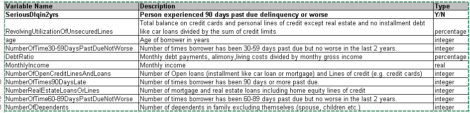

```python
 Image('data.png')
```

We divide features into three main groups

- static attributes: age, number of dependents,monthly income
- credit line: credit utilization, debt ratio, number of open loans, number of real estate loans
- overdue: 30-59days, 60-89days, over90days

### Get data

```python
import matplotlib.pyplot as plt
import pandas as pd
%matplotlib inline
```

```python
data = pd.read_csv('.\\GiveMeSomeCredit\\cs-training.csv').iloc[:,1:]
data.shape
```

```
(150000, 11)
```

```python
# split train and test
from sklearn.model_selection import train_test_split
train_X, test_X, train_y, test_y = train_test_split(data.drop('SeriousDlqin2yrs',axis=1),data['SeriousDlqin2yrs'],test_size=.3)
```

```python
data = pd.concat([train_X,train_y],axis=1)
```

```python
data.info(verbose=True,null_counts=True)
```

```
<class 'pandas.core.frame.DataFrame'>
Int64Index: 105000 entries, 4969 to 99754
Data columns (total 11 columns):
RevolvingUtilizationOfUnsecuredLines    105000 non-null float64
age                                     105000 non-null int64
NumberOfTime30-59DaysPastDueNotWorse    105000 non-null int64
DebtRatio                               105000 non-null float64
MonthlyIncome                           84181 non-null float64
NumberOfOpenCreditLinesAndLoans         105000 non-null int64
NumberOfTimes90DaysLate                 105000 non-null int64
NumberRealEstateLoansOrLines            105000 non-null int64
NumberOfTime60-89DaysPastDueNotWorse    105000 non-null int64
NumberOfDependents                      102295 non-null float64
SeriousDlqin2yrs                        105000 non-null int64
dtypes: float64(4), int64(7)
memory usage: 9.6 MB
```

```python
data.describe()
```

|  | RevolvingUtilizationOfUnsecuredLines | age | NumberOfTime30-59DaysPastDueNotWorse | DebtRatio | MonthlyIncome | NumberOfOpenCreditLinesAndLoans | NumberOfTimes90DaysLate | NumberRealEstateLoansOrLines | NumberOfTime60-89DaysPastDueNotWorse | NumberOfDependents | SeriousDlqin2yrs |
| --- | --- | --- | --- | --- | --- | --- | --- | --- | --- | --- | --- |
| count | 105000.000000 | 105000.000000 | 105000.000000 | 105000.000000 | 8.418100e+04 | 105000.000000 | 105000.000000 | 105000.000000 | 105000.000000 | 102295.000000 | 105000.000000 |
| mean | 6.295667 | 52.304886 | 0.417181 | 349.484224 | 6.654266e+03 | 8.442276 | 0.262505 | 1.017590 | 0.236438 | 0.758629 | 0.066324 |
| std | 277.377900 | 14.771964 | 4.146775 | 1938.905806 | 1.550295e+04 | 5.137439 | 4.123270 | 1.129103 | 4.108381 | 1.115994 | 0.248848 |
| min | 0.000000 | 0.000000 | 0.000000 | 0.000000 | 0.000000e+00 | 0.000000 | 0.000000 | 0.000000 | 0.000000 | 0.000000 | 0.000000 |
| 25% | 0.029590 | 41.000000 | 0.000000 | 0.174660 | 3.400000e+03 | 5.000000 | 0.000000 | 0.000000 | 0.000000 | 0.000000 | 0.000000 |
| 50% | 0.153654 | 52.000000 | 0.000000 | 0.367004 | 5.399000e+03 | 8.000000 | 0.000000 | 1.000000 | 0.000000 | 0.000000 | 0.000000 |
| 75% | 0.557776 | 63.000000 | 0.000000 | 0.869591 | 8.248000e+03 | 11.000000 | 0.000000 | 2.000000 | 0.000000 | 1.000000 | 0.000000 |
| max | 50708.000000 | 109.000000 | 98.000000 | 329664.000000 | 3.008750e+06 | 58.000000 | 98.000000 | 54.000000 | 98.000000 | 20.000000 | 1.000000 |

```python
print('default rate: ',data['SeriousDlqin2yrs'].sum()/data['SeriousDlqin2yrs'].count())
```

[output not shown]

```python
# plot distributions
targetcol = 'SeriousDlqin2yrs'
feacols = [x for x in data.columns if x!=targetcol]
attr1 = [ 'age','MonthlyIncome', 'NumberOfDependents']
attr2 = ['RevolvingUtilizationOfUnsecuredLines', 'NumberOfOpenCreditLinesAndLoans', 'NumberRealEstateLoansOrLines','DebtRatio']
attr3 = [ 'NumberOfTime30-59DaysPastDueNotWorse', 'NumberOfTime60-89DaysPastDueNotWorse', 'NumberOfTimes90DaysLate']
```

We remove outliers at 99.9 percentile.

```python
data.quantile(.999)  # we will cut outliers over 99.9%
```

```
RevolvingUtilizationOfUnsecuredLines     1512.037
age                                        94.000
NumberOfTime30-59DaysPastDueNotWorse       98.000
DebtRatio                               10527.044
MonthlyIncome                           80348.320
NumberOfOpenCreditLinesAndLoans            35.000
NumberOfTimes90DaysLate                    98.000
NumberRealEstateLoansOrLines                9.000
NumberOfTime60-89DaysPastDueNotWorse       98.000
NumberOfDependents                          6.000
SeriousDlqin2yrs                            1.000
Name: 0.999, dtype: float64
```

```python
for c in feacols:
    data = data.loc[data[c]<=data.quantile(.999)[c]]
```

```python
# drop age ==0
data = data[data['age']>0]
```

```python
data.median()
```

```
RevolvingUtilizationOfUnsecuredLines       0.177278
age                                       51.000000
NumberOfTime30-59DaysPastDueNotWorse       0.000000
DebtRatio                                  0.295824
MonthlyIncome                           5399.000000
NumberOfOpenCreditLinesAndLoans            8.000000
NumberOfTimes90DaysLate                    0.000000
NumberRealEstateLoansOrLines               1.000000
NumberOfTime60-89DaysPastDueNotWorse       0.000000
NumberOfDependents                         0.000000
SeriousDlqin2yrs                           0.000000
dtype: float64
```

We fill missing values with median.

```python
data.loc[data['MonthlyIncome'].isnull(),'MonthlyIncome'] = data['MonthlyIncome'].median()
data.loc[data['NumberOfDependents'].isnull(),'NumberOfDependents'] = data['NumberOfDependents'].median()
```

```python
test_X.loc[test_X['MonthlyIncome'].isnull(),'MonthlyIncome'] = 5400
test_X.loc[test_X['NumberOfDependents'].isnull(),'NumberOfDependents'] = 0
```

### Features set 1: 'age','MonthlyIncome', 'NumberOfDependents'

```
age
```

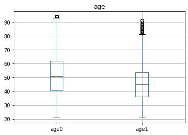

```
MonthlyIncome
```

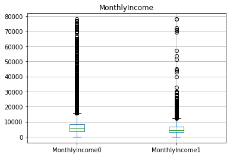

```
NumberOfDependents
```

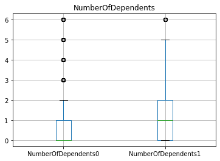

```python
for c in attr1:
    print(c)
    p1 = data.loc[data[targetcol]==0,[c]]
    p1.rename(columns={c:c+'0'},inplace=True)
    p2 = data.loc[data[targetcol]==1,[c]]
    p2.rename(columns={c:c+'1'},inplace=True)
    pd.concat([p1,p2],axis=1).boxplot()
    plt.title(c)
    plt.show()
```

### Features set 2:

- 'RevolvingUtilizationOfUnsecuredLines', 'NumberOfOpenCreditLinesAndLoans', 'NumberRealEstateLoansOrLines','DebtRatio'

```
RevolvingUtilizationOfUnsecuredLines
```

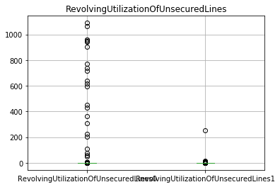

```
NumberOfOpenCreditLinesAndLoans
```

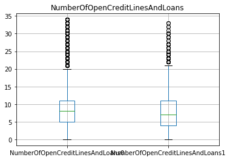

```
NumberRealEstateLoansOrLines
```

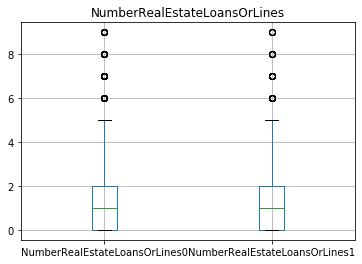

```
DebtRatio
```

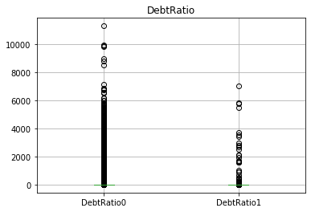

```python
for c in attr2:
    print(c)
    p1 = data.loc[data[targetcol]==0,[c]]
    p1.rename(columns={c:c+'0'},inplace=True)
    p2 = data.loc[data[targetcol]==1,[c]]
    p2.rename(columns={c:c+'1'},inplace=True)
    pd.concat([p1,p2],axis=1).boxplot()
    plt.title(c)
    plt.show()
```

### Features set 3:

'NumberOfTime30-59DaysPastDueNotWorse', 'NumberOfTime60-89DaysPastDueNotWorse', 'NumberOfTimes90DaysLate'

```
NumberOfTime30-59DaysPastDueNotWorse
```

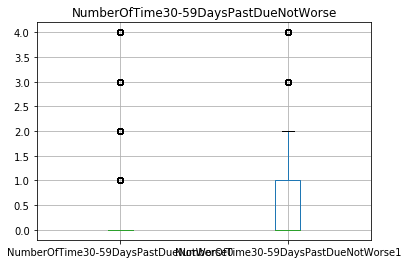

```
NumberOfTime60-89DaysPastDueNotWorse
```

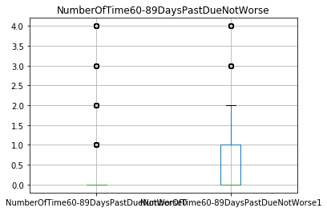

```
NumberOfTimes90DaysLate
```

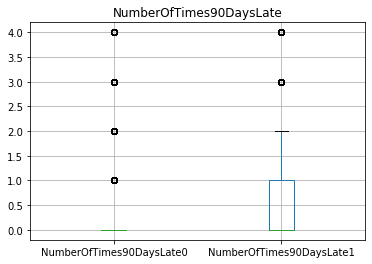

```python
for c in attr3:
    print(c)
    p1 = data.loc[(data[targetcol]==0)&(data[c]<5),[c]]
    p1.rename(columns={c:c+'0'},inplace=True)
    p2 = data.loc[(data[targetcol]==1)&(data[c]<5),[c]]
    p2.rename(columns={c:c+'1'},inplace=True)
    pd.concat([p1,p2],axis=1).boxplot()
    plt.title(c)
    plt.show()
```

People who has a default history might are more likely to default again. We also notice some outliers, e.g. default greater than 5 times in the data.

### Feature correlation

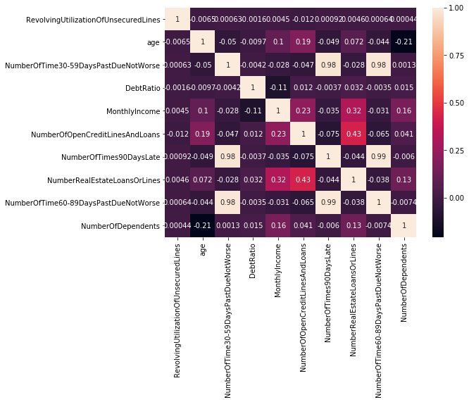

```python
import seaborn as sns
plt.figure(figsize=(8,6))
sns.heatmap(data[feacols].corr(),annot=True)
```

#### A few observations:

- Monthly income is correlated to number of credit lines/real estate loans
- It's highly likely that initial default will extend over 60 and 90days

### Feature engineering

- Combine open credit lines and real estate lines into one feature TotalLines
- Combone number of defaults into one feature - DefaultHist to indicate whether there's default

```python
data['TotalLines'] = data['NumberOfOpenCreditLinesAndLoans'] +data['NumberRealEstateLoansOrLines']
data['DefaultHist'] = data.apply(lambda x:int(x['NumberOfTime30-59DaysPastDueNotWorse']==1)+int(x['NumberOfTime60-89DaysPastDueNotWorse']==1)+int(x['NumberOfTimes90DaysLate']),axis=1)
```

```python
test_X['TotalLines'] = test_X['NumberOfOpenCreditLinesAndLoans'] +test_X['NumberRealEstateLoansOrLines']
test_X['DefaultHist'] = test_X.apply(lambda x:int(x['NumberOfTime30-59DaysPastDueNotWorse']==1)+int(x['NumberOfTime60-89DaysPastDueNotWorse']==1)+int(x['NumberOfTimes90DaysLate']),axis=1)
```

```python
# data.drop(['NumberOfOpenCreditLinesAndLoans','NumberRealEstateLoansOrLines','NumberOfTime30-59DaysPastDueNotWorse','NumberOfTime60-89DaysPastDueNotWorse','NumberOfTimes90DaysLate'],axis=1,inplace=True)
```

```
array([[<matplotlib.axes._subplots.AxesSubplot object at 0x00000297E7F71898>,
      dtype=object)
```

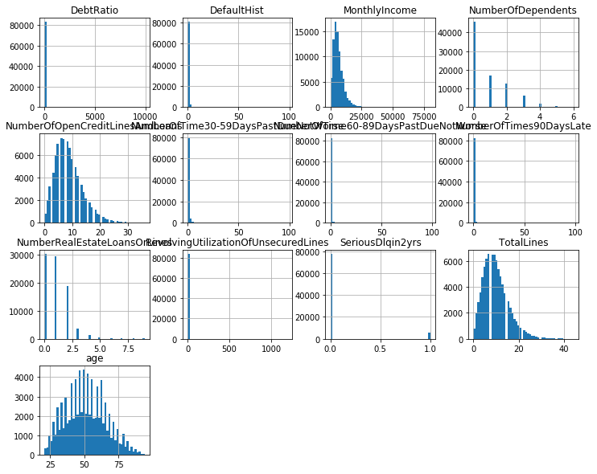

```python
data.hist(bins=50,figsize=(12,10))
```

```python
data.info()
```

[output not shown]

```python
# value counts for integers
int_cols =  ['age','NumberOfTime30-59DaysPastDueNotWorse','NumberOfOpenCreditLinesAndLoans','NumberOfTimes90DaysLate','NumberRealEstateLoansOrLines','NumberOfTime60-89DaysPastDueNotWorse','NumberOfDependents','TotalLines']
for c in int_cols:
    print(c,' unique counts: ',data[c].nunique())
    data[c].value_counts().sort_values(ascending=False).head(10)
```

```
age  unique counts:  74
```

```
49    2257
48    2199
46    2185
47    2158
50    2128
52    2116
51    2091
45    2085
53    2077
54    2065
Name: age, dtype: int64
```

```
NumberOfTime30-59DaysPastDueNotWorse  unique counts:  16
```

```
0     69770
1      9394
2      2760
3      1036
4       455
5       202
98      105
6        86
7        30
8        14
Name: NumberOfTime30-59DaysPastDueNotWorse, dtype: int64
```

```
NumberOfOpenCreditLinesAndLoans  unique counts:  37
```

```
6     7557
7     7453
8     7251
5     7039
9     6643
4     6044
10    5649
11    4944
3     4485
12    4145
Name: NumberOfOpenCreditLinesAndLoans, dtype: int64
```

```
NumberOfTimes90DaysLate  unique counts:  17
```

```
0     79149
1      3042
2       861
3       374
4       160
98      105
5        74
6        37
7        24
8        12
Name: NumberOfTimes90DaysLate, dtype: int64
```

```
NumberRealEstateLoansOrLines  unique counts:  10
```

```
0    30202
1    29184
2    18695
3     3731
4     1272
5      399
6      184
7      101
8       53
9       44
Name: NumberRealEstateLoansOrLines, dtype: int64
```

```
NumberOfTime60-89DaysPastDueNotWorse  unique counts:  11
```

```
0     79454
1      3345
2       663
3       193
98      105
4        65
5        21
6        12
7         3
96        3
Name: NumberOfTime60-89DaysPastDueNotWorse, dtype: int64
```

```
NumberOfDependents  unique counts:  7
```

```
0.0    45521
1.0    17059
2.0    12735
3.0     6125
4.0     1838
5.0      489
6.0       98
Name: NumberOfDependents, dtype: int64
```

```
TotalLines  unique counts:  43
```

```
7     6534
8     6492
9     6438
6     6165
10    6061
5     5527
11    5357
12    4775
4     4735
13    4197
Name: TotalLines, dtype: int64
```

### Run a tree model quickly to check feature importances

```python
# run a feature importance
from xgboost.sklearn import XGBClassifier
clf = XGBClassifier(learning_rate=0.3,max_depth=6,n_estimators=100,seed=1000)
clf.fit(data.drop(targetcol,axis=1),data[targetcol],eval_metric='auc')
```

```
XGBClassifier(base_score=0.5, booster='gbtree', colsample_bylevel=1,
              colsample_bynode=1, colsample_bytree=1, gamma=0,
              learning_rate=0.3, max_delta_step=0, max_depth=6,
              min_child_weight=1, missing=None, n_estimators=100, n_jobs=1,
              nthread=None, objective='binary:logistic', random_state=0,
              reg_alpha=0, reg_lambda=1, scale_pos_weight=1, seed=1000,
              silent=None, subsample=1, verbosity=1)
```

```python
clf.feature_importances_,data.columns
```

[output not shown]

[figure not shown]

```python
from xgboost import plot_importance
plot_importance(clf,max_num_features=20)
```

```
auc 0.8348018811882392
```

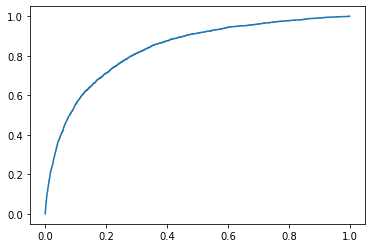

```python
from sklearn.metrics import roc_curve,roc_auc_score
pred_y = clf.predict_proba(test_X)[:,1]
fpr,tpr,_ = roc_curve(test_y,pred_y)
auc = roc_auc_score(test_y,pred_y)
print('auc',auc)
plt.plot(fpr,tpr)
```

We can see with little feature selection, xgboost returns auc of 0.8. DebtRatio,Utilization of loans, Monthly Income and Age are the key factors.

### Preprocessing - Discretionize features

```python
import numpy as np
import scipy.stats as stats
# important algo
def mono_bin(Y,X, n=20):
    r = 0
    good = Y.sum()
    bad = Y.count()-good
    # find optimal binning strategy
    while np.abs(r)<1:
        d1 = pd.DataFrame({'X':X,'Y':Y,'Bucket':pd.qcut(X.rank(method='first'),n)})
        d2 = d1.groupby('Bucket',as_index=True)
        r,p = stats.spearmanr(d2.mean().X,d2.mean().Y)
        n = n - 1
    d3 = pd.DataFrame(d2.X.min(),columns=['min'])
    d3['min'] = d2.min().X
    d3['max'] = d2.max().X
    d3['sum'] = d2.sum().Y
    d3['total'] = d2.count().Y
    d3['rate'] = d2.mean().Y
    d3['woe'] = np.log((d3['rate']/(1-d3['rate']))/(good/bad))
    d3['goodattribute'] = d3['sum']/good
    d3['badattribute'] = (d3['total']-d3['sum'])/bad
    iv = ((d3['goodattribute'] - d3['badattribute'])*d3['woe']).sum()
    d4 = (d3.sort_values(by='min')).reset_index(drop=True)
    print(iv)
    print("="*60)
    print(d4)
    cut = []
    cut.append(float('-inf'))
    for i in range(1,n+1):
        qua = X.quantile(i/(n+1))
        cut.append(round(qua,4))
    cut.append(float('inf'))
    woe = list(d4['woe'].round(3))
    return [d4,iv,cut,woe]
```

```python
fea_cols = [x for x in data.columns if x !=targetcol]
pinf = float('inf')
ninf = float('-inf')
bin_params = {}
for c in fea_cols:
    print(c)
    bin_params[c]=mono_bin(data[targetcol],data[c],n=(20 if data[c].nunique()>=15 else data[c].nunique()))
```

```
RevolvingUtilizationOfUnsecuredLines
0.9044374927072318
============================================================
        min          max   sum  total      rate       woe  goodattribute  \
0  0.000000     0.034670   440  20942  0.021010 -1.240492       0.076046
1  0.034682     0.176565   496  20941  0.023686 -1.117907       0.085724
2  0.176567     0.578671  1110  20941  0.053006 -0.281875       0.191842
3  0.578684  1563.000000  3740  20942  0.178588  1.075071       0.646388

   badattribute
0      0.262914
1      0.262183
2      0.254309
3      0.220595
age
0.1962670642925381
============================================================
   min  max   sum  total      rate       woe  goodattribute  badattribute
0   21   34  1125  10471  0.107440  0.483846       0.194435      0.119851
1   34   40   991  10471  0.094642  0.342786       0.171275      0.121570
2   40   46   873  10470  0.083381  0.203741       0.150881      0.123070
3   46   51   858  10471  0.081941  0.184744       0.148289      0.123275
4   51   56   730  10471  0.069716  0.009957       0.126167      0.124917
5   56   61   537  10470  0.051289 -0.316609       0.092810      0.127379
6   61   68   394  10471  0.037628 -0.640649       0.068095      0.129225
7   68   94   278  10471  0.026550 -1.000824       0.048047      0.130713
NumberOfTime30-59DaysPastDueNotWorse
0.0
============================================================
   min  max   sum  total      rate  woe  goodattribute  badattribute
0    0   98  5786  83766  0.069073  0.0            1.0           1.0
DebtRatio
0.0
============================================================
   min     max   sum  total      rate  woe  goodattribute  badattribute
0  0.0  9958.0  5786  83766  0.069073  0.0            1.0           1.0
MonthlyIncome
0.077387712532522
============================================================
      min      max   sum  total      rate       woe  goodattribute  \
```

[output cut: 22 more lines]

```
============================================================
   min  max   sum  total      rate  woe  goodattribute  badattribute
0    0    9  5786  83766  0.069073  0.0            1.0           1.0
NumberOfTime60-89DaysPastDueNotWorse
0.0
============================================================
   min  max   sum  total      rate  woe  goodattribute  badattribute
0    0   98  5786  83766  0.069073  0.0            1.0           1.0
NumberOfDependents
0.03124891020276051
============================================================
   min  max   sum  total      rate       woe  goodattribute  badattribute
0  0.0  0.0  1629  27922  0.058341 -0.180325       0.281542      0.337176
1  0.0  1.0  1780  27922  0.063749 -0.085919       0.307639      0.335240
2  1.0  6.0  2377  27922  0.085130  0.226409       0.410819      0.327584
```

```python
def self_bin(Y,X,cat):
    good=Y.sum()
    bad=Y.count()-good
    d1=pd.DataFrame({'X':X,'Y':Y,'Bucket':pd.cut(X,cat)})
    d2=d1.groupby('Bucket', as_index = True)
    d3 = pd.DataFrame(d2.X.min(), columns=['min'])
    d3['min'] = d2.min().X
    d3['max'] = d2.max().X
    d3['sum'] = d2.sum().Y
    d3['total'] = d2.count().Y
    d3['rate'] = d2.mean().Y
    d3['woe'] = np.log((d3['rate'] / (1 - d3['rate'])) / (good / bad))
    d3['goodattribute'] = d3['sum'] / good
    d3['badattribute'] = (d3['total'] - d3['sum']) / bad
    iv = ((d3['goodattribute'] - d3['badattribute']) * d3['woe']).sum()
    d4 = (d3.sort_index(by='min'))
    print("=" * 60)
    print(d4)
    woe = list(d4['woe'].round(3))
    return [d4, iv,woe]
```

```python
selfbins = {'DebtRatio':[ninf,0.36,0.435, 0.76, pinf],
  'NumberOfTime30-59DaysPastDueNotWorse': [ninf, 0, 1, 3, 5, pinf],
'NumberOfOpenCreditLinesAndLoans':[ninf, 1, 2, 3, 5, pinf],
'NumberOfTimes90DaysLate': [ninf, 0, 1, 3, pinf],
'NumberRealEstateLoansOrLines': [ninf, 0, 3, pinf],
 'NumberOfTime60-89DaysPastDueNotWorse': [ninf, 0, 1, 3, pinf],
'NumberOfDependents': [ninf, 0, 1, 2, 3, 5, pinf],
            'TotalLines':[ninf,2,4,5,pinf],
             'DefaultHist':[ninf,0,1,pinf],
            }
```

```python
selfbin_params = {}
for c in selfbins.keys():
    print(c)
    selfbin_params[c] = self_bin(data[targetcol],data[c],selfbins[c])
```

```
DebtRatio
============================================================
                    min          max   sum  total      rate       woe  \
Bucket
(-inf, 0.36]   0.000000     0.359981  2927  50321  0.058167 -0.183506
(0.36, 0.435]  0.360006     0.434995   551   8273  0.066602 -0.039083
(0.435, 0.76]  0.435008     0.759978  1435  16696  0.085949  0.236875
(0.76, inf]    0.760032  9958.000000   873   8476  0.102997  0.436649

               goodattribute  badattribute
Bucket
(-inf, 0.36]        0.505876      0.607771
(0.36, 0.435]       0.095230      0.099025
(0.435, 0.76]       0.248012      0.195704
(0.76, inf]         0.150881      0.097499
NumberOfTime30-59DaysPastDueNotWorse
============================================================
             min  max   sum  total      rate       woe  goodattribute  \
Bucket
(-inf, 0.0]    0    0  2922  69667  0.041942 -0.527600       0.505012
(0.0, 1.0]     1    1  1367   9380  0.145736  0.832565       0.236260
(1.0, 3.0]     2    3  1079   3828  0.281870  1.665809       0.186485
(3.0, 5.0]     4    5   287    643  0.446345  2.385563       0.049602
(5.0, inf]     6   98   131    248  0.528226  2.714035       0.022641

             badattribute
Bucket
(-inf, 0.0]      0.855925
(0.0, 1.0]       0.102757
(1.0, 3.0]       0.035253
(3.0, 5.0]       0.004565
(5.0, inf]       0.001500
NumberOfOpenCreditLinesAndLoans
============================================================
             min  max   sum  total      rate       woe  goodattribute  \
Bucket
(-inf, 1.0]    0    1   486   2885  0.168458  1.004413       0.083996
(1.0, 2.0]     2    2   319   3305  0.096520  0.364512       0.055133
(2.0, 3.0]     3    3   391   4625  0.084541  0.218816       0.067577
(3.0, 5.0]     4    5   917  13056  0.070236  0.017940       0.158486
```

[output cut: 10 more lines]

```
============================================================
             min  max   sum  total      rate       woe  goodattribute  \
Bucket
(-inf, 0.0]    0    0  3835  79040  0.048520 -0.375037       0.662807
(0.0, 1.0]     1    1  1010   3040  0.332237  1.902926       0.174559
(1.0, 3.0]     2    3   652   1234  0.528363  2.714585       0.112686
(3.0, inf]     4   98   289    452  0.639381  3.173688       0.049948

             badattribute
Bucket
(-inf, 0.0]      0.964414
(0.0, 1.0]       0.026032
(1.0, 3.0]       0.007463
(3.0, inf]       0.002090
NumberRealEstateLoansOrLines
```

```
============================================================
             min  max   sum  total      rate       woe  goodattribute  \
Bucket
(-inf, 0.0]    0    0  2587  30330  0.085295  0.228527       0.447114
(0.0, 3.0]     1    3  2945  51370  0.057329 -0.198896       0.508987
(3.0, inf]     4    9   254   2066  0.122943  0.636159       0.043899

             badattribute
Bucket
(-inf, 0.0]      0.355771
(0.0, 3.0]       0.620993
(3.0, inf]       0.023237
NumberOfTime60-89DaysPastDueNotWorse
============================================================
             min  max   sum  total      rate       woe  goodattribute  \
Bucket
(-inf, 0.0]    0    0  4226  79361  0.053250 -0.277019       0.730384
(0.0, 1.0]     1    1  1005   3376  0.297690  1.742687       0.173695
(1.0, 3.0]     2    3   437    829  0.527141  2.709683       0.075527
(3.0, inf]     4   98   118    200  0.590000  2.964977       0.020394

             badattribute
Bucket
(-inf, 0.0]      0.963516
(0.0, 1.0]       0.030405
(1.0, 3.0]       0.005027
(3.0, inf]       0.001052
NumberOfDependents
============================================================
             min  max   sum  total      rate       woe  goodattribute  \
Bucket
(-inf, 0.0]  0.0  0.0  2665  45519  0.058547 -0.176584       0.460595
(0.0, 1.0]   1.0  1.0  1249  16962  0.073635  0.068866       0.215866
(1.0, 2.0]   2.0  2.0  1062  12818  0.082852  0.196801       0.183546
(2.0, 3.0]   3.0  3.0   559   6001  0.093151  0.325259       0.096613
(3.0, 5.0]   4.0  5.0   236   2354  0.100255  0.406615       0.040788
(5.0, inf]   6.0  6.0    15    112  0.133929  0.734350       0.002592

             badattribute
Bucket
```

[output cut: 19 more lines]

```
(4.0, 5.0]       0.065401
(5.0, inf]       0.772198
DefaultHist
============================================================
             min  max   sum  total      rate       woe  goodattribute  \
Bucket
(-inf, 0.0]    0    0  2587  69045  0.037468 -0.645060       0.447114
(0.0, 1.0]     1    1  1673  11267  0.148487  0.854492       0.289146
(1.0, inf]     2   98  1526   3454  0.441807  2.367178       0.263740

             badattribute
Bucket
(-inf, 0.0]      0.852244
(0.0, 1.0]       0.123032
(1.0, inf]       0.024724
```

```python
# plot iv
iv_dict = {}
for c in selfbins.keys():
    iv_dict[c] = selfbin_params[c][1]

for c in bincols:
    iv_dict[c] = bin_params[c][1]
```

```python
iv_dict
```

```
{'DebtRatio': 0.054546512342353165,
 'NumberOfTime30-59DaysPastDueNotWorse': 0.7130297381360078,
 'NumberOfOpenCreditLinesAndLoans': 0.073530530915878,
 'NumberOfTimes90DaysLate': 0.8332706189791632,
 'NumberRealEstateLoansOrLines': 0.05629627389778785,
 'NumberOfTime60-89DaysPastDueNotWorse': 0.5626749164293647,
 'NumberOfDependents': 0.03124891020276051,
 'TotalLines': 0.06296108164129768,
 'DefaultHist': 0.9690699450714034,
 'RevolvingUtilizationOfUnsecuredLines': 0.9044374927072318,
 'age': 0.1962670642925381,
 'MonthlyIncome': 0.077387712532522}
```

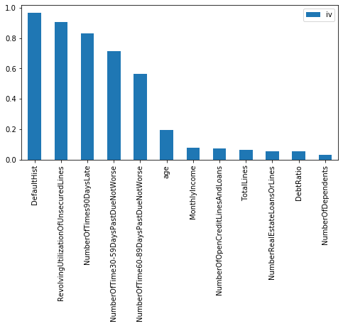

```python
pd.DataFrame.from_dict(iv_dict,orient='index').rename(columns={0:'iv'}).sort_values('iv',ascending=False).plot(kind='bar',figsize=(8,4))
```

```python
def convert_woe(x,cutoff,woe):
    for i in range(0,len(cutoff)-1):
        if x>cutoff[i] and x<=cutoff[i+1]:
            return woe[i]
    return None
```

```python
# convert all columns to woe
feacols = [x for x in data.columns if x!=targetcol]
bincols = ['RevolvingUtilizationOfUnsecuredLines','age','MonthlyIncome','NumberOfDependents']
selfbincols = [x for x in feacols if x not in bincols]
for c in bincols:
    print(c)
    data[c+'_woe'] = data[c].apply(lambda x:convert_woe(x,bin_params[c][2],bin_params[c][3]))
    test_X[c+'_woe'] = test_X[c].apply(lambda x:convert_woe(x,bin_params[c][2],bin_params[c][3]))

for c in selfbincols:
    print(c)
    data[c+'_woe'] = data[c].apply(lambda x:convert_woe(x,selfbins[c],selfbin_params[c][2]))
    test_X[c+'_woe'] = test_X[c].apply(lambda x:convert_woe(x,selfbins[c],selfbin_params[c][2]))
```

```
RevolvingUtilizationOfUnsecuredLines
age
MonthlyIncome
NumberOfDependents
NumberOfTime30-59DaysPastDueNotWorse
DebtRatio
NumberOfOpenCreditLinesAndLoans
NumberOfTimes90DaysLate
NumberRealEstateLoansOrLines
NumberOfTime60-89DaysPastDueNotWorse
TotalLines
DefaultHist
```

```python
data.to_csv('train.csv',index=False)
pd.concat([test_X,test_y],axis=1).to_csv('test.csv',index=False)
```

### Build logistic model

```python
import statsmodels.api as sm
X = data[[c+'_woe' for c in feacols]]
Y = data[targetcol]
X1=sm.add_constant(X)
logit=sm.Logit(Y,X1)
result=logit.fit()
print(result.summary())
```

```
Optimization terminated successfully.
         Current function value: 0.191730
         Iterations 8
                           Logit Regression Results
==============================================================================
Dep. Variable:       SeriousDlqin2yrs   No. Observations:                83766
Model:                          Logit   Df Residuals:                    83753
Method:                           MLE   Df Model:                           12
Date:                Wed, 11 Sep 2019   Pseudo R-squ.:                  0.2369
Time:                        22:12:59   Log-Likelihood:                -16060.
converged:                       True   LL-Null:                       -21045.
Covariance Type:            nonrobust   LLR p-value:                     0.000
============================================================================================================
                                               coef    std err          z      P>|z|      [0.025      0.975]
------------------------------------------------------------------------------------------------------------
const                                       -2.5635      0.017   -151.488      0.000      -2.597      -2.530
RevolvingUtilizationOfUnsecuredLines_woe     0.6055      0.018     33.952      0.000       0.571       0.640
age_woe                                      0.4115      0.040     10.294      0.000       0.333       0.490
NumberOfTime30-59DaysPastDueNotWorse_woe     0.4930      0.019     26.013      0.000       0.456       0.530
DebtRatio_woe                                0.9168      0.072     12.800      0.000       0.776       1.057
MonthlyIncome_woe                            0.2076      0.062      3.355      0.001       0.086       0.329
NumberOfOpenCreditLinesAndLoans_woe          0.1956      0.134      1.458      0.145      -0.067       0.458
NumberOfTimes90DaysLate_woe                  0.4856      0.022     21.956      0.000       0.442       0.529
NumberRealEstateLoansOrLines_woe             0.7636      0.071     10.738      0.000       0.624       0.903
NumberOfTime60-89DaysPastDueNotWorse_woe     0.3535      0.020     17.269      0.000       0.313       0.394
NumberOfDependents_woe                       0.3790      0.090      4.218      0.000       0.203       0.555
TotalLines_woe                              -0.3342      0.154     -2.163      0.031      -0.637      -0.031
DefaultHist_woe                              0.1221      0.024      5.076      0.000       0.075       0.169
============================================================================================================
```

```python
# drop NumberOfOpenCreditLinesAndLoans_woe , all coefficients are positive
X = data[[c+'_woe' for c in feacols if c not in ('NumberOfOpenCreditLinesAndLoans','TotalLines')]]
Y = data[targetcol]
X1=sm.add_constant(X)
logit=sm.Logit(Y,X1)
result=logit.fit()
print(result.summary())
```

```
Optimization terminated successfully.
         Current function value: 0.191765
         Iterations 8
                           Logit Regression Results
==============================================================================
Dep. Variable:       SeriousDlqin2yrs   No. Observations:                83766
Model:                          Logit   Df Residuals:                    83755
Method:                           MLE   Df Model:                           10
Date:                Wed, 11 Sep 2019   Pseudo R-squ.:                  0.2367
Time:                        22:14:41   Log-Likelihood:                -16063.
converged:                       True   LL-Null:                       -21045.
Covariance Type:            nonrobust   LLR p-value:                     0.000
============================================================================================================
                                               coef    std err          z      P>|z|      [0.025      0.975]
------------------------------------------------------------------------------------------------------------
const                                       -2.5632      0.017   -151.496      0.000      -2.596      -2.530
RevolvingUtilizationOfUnsecuredLines_woe     0.6003      0.017     34.430      0.000       0.566       0.635
age_woe                                      0.4060      0.040     10.183      0.000       0.328       0.484
NumberOfTime30-59DaysPastDueNotWorse_woe     0.4978      0.019     26.638      0.000       0.461       0.534
DebtRatio_woe                                0.9570      0.069     13.940      0.000       0.822       1.092
MonthlyIncome_woe                            0.1767      0.060      2.956      0.003       0.060       0.294
NumberOfTimes90DaysLate_woe                  0.4828      0.022     21.983      0.000       0.440       0.526
NumberRealEstateLoansOrLines_woe             0.7205      0.069     10.429      0.000       0.585       0.856
NumberOfTime60-89DaysPastDueNotWorse_woe     0.3542      0.020     17.316      0.000       0.314       0.394
NumberOfDependents_woe                       0.3839      0.090      4.274      0.000       0.208       0.560
DefaultHist_woe                              0.1204      0.024      5.011      0.000       0.073       0.167
============================================================================================================
```

```python
colselect = X.columns
```

We check the p values and coefficients. All pvalues smaller than 0.05 and coef is positive. Good to go.

#### Predict model

```
(0, 1)
```

```
(0, 1)
```

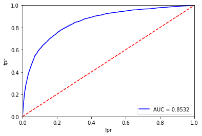

```python
from sklearn.metrics import roc_curve,auc
X3 = sm.add_constant(test_X[X.columns])
res = result.predict(X3)#进行预测
fpr, tpr, threshold = roc_curve(test_y, res)
rocauc = auc(fpr, tpr)#计算AUC
plt.plot(fpr, tpr, 'b', label='AUC = %0.4f' % rocauc)#生成ROC曲线
plt.legend(loc='lower right')
plt.plot([0, 1], [0, 1], 'r--')
plt.xlim([0, 1])
plt.ylim([0, 1])
plt.ylabel('tpr')
plt.xlabel('fpr')
plt.show()
```

interestingly, the auc under logistic regression is better than that of xgboost

### Convert to credit score

```python
# 我们取600分为基础分值，PDO为20（每高20分好坏比翻一倍），好坏比取20。
# We take 600 as base score, PDO is 20 (meaning for every 20 points, logit doubles)
# calculate basescore
import math
z = 20 / math.log(2)
q = 600 - 20 * math.log(20) / math.log(2)
baseScore = round(q + z * result.params[0], 0)
```

```python
print('regression coefficient:')
result.params
print('how score changes as woe changes')
z*result.params
```

```
regression coefficient:
```

```
const                                      -2.563215
RevolvingUtilizationOfUnsecuredLines_woe    0.600339
age_woe                                     0.406024
NumberOfTime30-59DaysPastDueNotWorse_woe    0.497778
DebtRatio_woe                               0.956975
MonthlyIncome_woe                           0.176718
NumberOfTimes90DaysLate_woe                 0.482843
NumberRealEstateLoansOrLines_woe            0.720508
NumberOfTime60-89DaysPastDueNotWorse_woe    0.354157
NumberOfDependents_woe                      0.383907
DefaultHist_woe                             0.120402
dtype: float64
```

```
how score changes as woe changes
```

```
const                                      -73.958754
RevolvingUtilizationOfUnsecuredLines_woe    17.322118
age_woe                                     11.715373
NumberOfTime30-59DaysPastDueNotWorse_woe    14.362825
DebtRatio_woe                               27.612451
MonthlyIncome_woe                            5.098997
NumberOfTimes90DaysLate_woe                 13.931903
NumberRealEstateLoansOrLines_woe            20.789470
NumberOfTime60-89DaysPastDueNotWorse_woe    10.218798
NumberOfDependents_woe                      11.077205
DefaultHist_woe                              3.474076
dtype: float64
```

```python
# 各项部分分数
for c in colselect:
    data[c+'_s']=data[c]*z*result.params[c]
    test_X[c+'_s']=test_X[c]*z*result.params[c]
```

```python
data['score'] = round(q+data[[c+'_s' for c in colselect]].sum(axis=1),0)
test_X['score'] = round(q+test_X[[c+'_s' for c in colselect]].sum(axis=1),0)
```

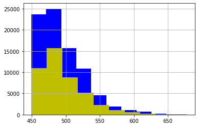

```python
data['score'].hist(color='b')
test_X['score'].hist(color='y')
```